# screenr Tutorial

Steve Gutreuter

sgutreuter@gmail.com

# Introduction

The screenr package enables easy development and validation of pre-testing screening tools of the sort reviewed by Clemens et al [1]. Universal testing for a condition can be impractical if the test procedure is relatively expensive and the condition is rare. Alternatively, testing only those subjects having a sufficiently large probability of testing positive may be a viable alternative if a screening procedure can be developed which has an acceptable sensitivity. That may be possible if easily measured/recorded risk factors for test positivity can be identified.

This vignette demonstrates the development and validation of such a screening tool using lasso-like *L*1 regularization [2] of logistic models, as implemented in the glmpath package [3]. The screenr package also supports maximum-likelihood estimation of logistic model parameters, but the regularization approach is simpler to use, automatically prevents over-fitting, and handles separation of outcomes by some predictor(s). Model performance is evaluating using receiver-operating characteristics [4,5].

# An (Artificial) Example

[Unicorns](https://www.britannica.com/topic/unicorn) suffer an epidemic of infection by the Unicorn Immunodeficiency Virus (UIV). There is currently no cure for UIV infection, but highly effective antiretrovial therapy has the potential to both block forward transmission and to avert death from opportunistic infections associated with UIV infection. Therefore it is critically important that UIV infection is detected, and that infected unicorns are enrolled in treatment. However, UIV infection is sufficiently rare that universal testing of unicorns at health-care entry points is impractical.

A sample of 6000 properly consented unicorns were enrolled in a study aimed at evidence-based targeting of testing for UIV infection. The subjects were administered a seven-item questionnaire identifying the presence or absence of putative risk factors for UIV infection. The prevalence of UIV is low, and therefore universal testing was deemed impractical. The challenge then is to identify unicorns who should be prioritized for testing. Because UIV is transmissible and fatal if untreated, it is important that the screening tool have an acceptably high sensitivity. The screenr package enables development and validation of such screening tools.

The screening questionnaire included seven questions which were selected based on published information on infection risk. The data consists of the responses to the screening questions Q1, …, Q7 (coded as 1 for an affirmative (yes) response and 0 for a negative response) and the testing outcome (testresult), again coded 0 and 1 for negative and positive results, respectively.

**NOTE:** It is critically important that all of the putative risk factors have a *positive* association with the outcome. That is, the questionnaire must be designed so that affirmative (yes) responses are hypothesized to indicate an *increased* risk of UIV infection.

The data from the unicorn study look like:

```r
## The first six lines of the unicorn screening data:
head(unicorns)
```

```
#>   ID Q1 Q2 Q3 Q4 Q5 Q6 Q7 testresult
#> 1  1  0  0  0  0  0  0  1          0
#> 2  2  0  0  0  0  0  0  0          0
#> 3  3  0  0  0  0  0  0  0          0
#> 4  4  1  0  0  0  0  0  1          0
#> 5  5  1  0  0  1  1  0  1          0
#> 6  6  0  0  0  0  0  0  0          0
```

# Screening Tool Development

Screening-tool development and thorough validation consists of four steps:

1. Model fitting
2. Selection of a screening threshold
3. Implementation
4. External validation on entirely new data

In practice, unfortunately, the fourth step is often neglected due to resource limitations.

## Model fitting

The first step is estimation of the logistic-model parameters from the training data. A method known as *L*1 regularization has desirable properties for that task [2,3]. The function `lasso_screenr()` provides easy, integrated access to the *L*1 regularization algorithm of Park and Hastie [3], as implemented in the glmpath R package, using a convenient formula interface:

```r
uniobj1 <- lasso_screenr(testresult ~ Q1 + Q2 + Q3 + Q4 + Q5 + Q6 + Q7,
                         data = unicorns, Nfolds = 10)
```

[output not shown]

```r
class(uniobj1)
```

```
#> [1] "lasso_screenr"
```

The formula `testresult ~ Q1 + Q2 + Q3 + Q4 + Q5 + Q6 + Q7` is an expression of the statement “predict `testresult` from the seven predictor variables `Q1`, …, `Q7`. The argument `Nfolds = 10` specifies the desired number of partitions (folds) to be used for cross validation (discussed under”Selection of a screening threshold", below).

The fitting algorithm computes logit-scale coefficients along the entire regularization path, and has the effect of selecting covariates based on penalization of *L*1-norm of their coefficients, similar to the ordinary lasso [2]. Unlike the lasso, the algorithm also imposes a very small penalty on the *L*2-norm, which eliminates adverse effects of any strong correlations among the predictors which provides useful estimates even if the response variable is separable by the predictors (albeit unlikely in test-screening applications). Two solutions along the regularization path which yield the smallest AIC and BIC values, denoted `"minAIC"` and `"minBIC"`, respectively, are given special status. Those are likely the most useful solutions in nearly all settings.

The resulting `lasso_screenr`-class object (`uniobj1`) includes the results from regularization and performance measures from the fits to all of the data, and from *k*-fold cross validation. The resulting object, `uniobj1`, contains all of the information need to develop and (internally) validate a screening tool for diagnostic tests.

For example, the logit-scale coefficients for the special solutions are obtained using:

```r
coef(uniobj1)
```

```
#>           AIC-best model BIC-best model
#> Intercept     -7.5686085  -6.8332612492
#> Q1             2.7678353   2.4684998411
#> Q2             1.5602599   1.1002686774
#> Q3             2.8916922   2.5756626175
#> Q4             0.0000000   0.0000000000
#> Q5             1.8222182   1.5786706266
#> Q6             0.3637801   0.0006562222
#> Q7             0.8432769   0.5814322197
```

One can also obtain the adjusted odds ratios and/or omit the intercept. For example, the adjusted odds ratios for the seven predictors can be obtained using:

```r
coef(uniobj1, or = TRUE, intercept = FALSE)
```

```
#>    AIC-best model BIC-best model
#> Q1      15.924125      11.804725
#> Q2       4.760058       3.004973
#> Q3      18.023784      13.140021
#> Q4       1.000000       1.000000
#> Q5       6.185564       4.848506
#> Q6       1.438758       1.000656
#> Q7       2.323970       1.788598
```

The adjusted odds ratios for Q4 are 1.0, again indicating that Q4 was not predictive of the test result.

One can also examine the coefficients everywhere the active set changed along the regularization path for either of the special fits:

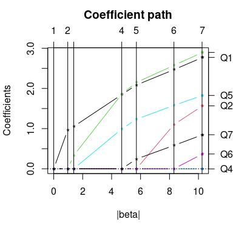

```r
pathobj <- get_what(from = uniobj1, what = "glmpathObj", model = "minAIC")
plot(pathobj)
```

where the horizontal axis is the *L*1-norm of the coefficient vector (see [3] for details).

The screenr package provides the following methods for `lasso-screenr`-class objects:

```r
methods(class = "lasso_screenr")
```

```
#> [1] coef     get_what ntpp     plot     predict  print    summary
#> see '?methods' for accessing help and source code
```

The methods should make it unnecessary to access components of `lasso_screenr`-class objects directly using R code similar to `object$component`.

## Selection of a screening threshold

The next task is identifying whether sufficiently effective pre-test screening is possible and, if so, selecting the most appropriate screening threshold. That task requires careful consideration and expert judgment, neither of which are provided by the screenr package. However the screenr package does provide the results that are most relevant to that task.

```r
roc_maximas <- get_what(from = uniobj1, what = "ROCci", se.min = 0.9)
print(roc_maximas)
```

```
#>     Threshold Sensitivity    se.lcl    se.ucl Specificity    sp.lcl    sp.ucl
#> 1 0.001291307   1.0000000 1.0000000 1.0000000   0.2938336 0.2822251 0.3054421
#> 2 0.001411250   0.9896907 0.9690722 1.0000000   0.3874301 0.3750635 0.4003049
#> 3 0.004126745   0.9793814 0.9484536 1.0000000   0.5917330 0.5791970 0.6039302
#> 4 0.006623639   0.9690722 0.9278351 1.0000000   0.6186685 0.6063019 0.6305269
#> 5 0.007395935   0.9484536 0.8969072 0.9896907   0.6439099 0.6317127 0.6559419
#> 6 0.007522623   0.9278351 0.8762887 0.9793814   0.6644926 0.6525496 0.6759317
#> 7 0.007665094   0.9175258 0.8556701 0.9690722   0.6791462 0.6671142 0.6906658
#> 8 0.010190759   0.9072165 0.8453608 0.9587629   0.7472472 0.7360622 0.7582585
```

For example, suppose we have screening results on two additional unicorns who have not been tested previously. We can compute their probabilities of testing positive using the `predict` method for `lasso_screenr`-class objects:

```r
new_corns <- data.frame(ID = c("Alice D.", "Bernie P."),
                        testresult = c(NA, NA),
                        Q1 = c(0, 0), Q2 = c(0, 0), Q3 = c(0, 1),
                        Q4 = c(0, 0), Q5 = c(0, 1), Q6 = c(0, 0),
                        Q7 = c(0, 0))
new <- predict(uniobj1,  newdata = new_corns )
print(new)
```

```
#>   testresult Q1 Q2 Q3 Q4 Q5 Q6 Q7 phat_minAIC phat_minBIC
#> 1         NA  0  0  0  0  0  0  0 0.000516144  0.00107618
#> 2         NA  0  0  1  0  1  0  0 0.054438977  0.06422828
```

## Implementation

There are two basic approaches to implementation of test screening based on the results from the unicorn study.

### Implementation based on probabilities of testing positive

First, a smartphone or tablet application could be developed which contains the questionnaire and code that mimics the functionality of the `predict` method.

The predicted probability of infection is given by
$$P = \frac{1}{1 + exp(-Xb)}$$
where *X* is a (design) matrix containing values of 1 in the first column and the 0/1 question responses in the remaining columns, and *b* is a column vector of the estimated logit-scale coefficients, including the intercept.

The interviewer would enter the responses to the questions and the application would indicate whether the subject should be referred for testing based on the internally computed value of *P*. This is the ideal approach, and should be used wherever possible. However, a simpler approach may be needed in many health-care settings.

**NOTE:** Screening questions for which estimated coefficients equal 0 (and those zero-valued coefficients) can and should be eliminated from the screening application.

### Simplified implementation based on question weights

Alternatively, the non-zero coefficient estimates could be rounded to whole numbers between 1 and *m*, where *m* is some number from, say, 3 to 10. Those rounded values are used as weights for the question responses. The score for an individual is the sum of the question weights. The choice of *m* involves a trade-off. Small values, say *m* = 3, make it easy to add-up or tally the scores. However, they may also result in degraded performance in terms of sensitivity and specificity. Large values for *m* may approximate the performance of screening based on the predicted probabilities of infection, but require more difficult additions which are vulnerable to human error.

We can explore this strategy for UIV screening in unicorns using the `easy_tool` function:

```r
et_3 <- easy_tool(uniobj1, max = 3, model = "minAIC", crossval = TRUE)
class(et_3)
```

```
#> [1] "easy_tool"
```

Recall that `uniobj1` contains the results of lasso estimation. The argument `max` represents *m*, in this case 3. The remaining arguments specify creation of question weights from the AIC-best model with performance base on the cross-validated results in `uniobj1`. The resulting object, `et_3`, is of class `easy_tool`.

Methods for that class are found by executing:

```r
methods(class = "easy_tool")
```

```
#> [1] get_what ntpp     plot     print    summary
#> see '?methods' for accessing help and source code
```

The question weights can be extracted using the `get_what` method:

```r
qwts <- get_what(from = et_3, what = "QuestionWeights")
print(qwts)
```

```
#>    [,1]
#> Q1    3
#> Q2    2
#> Q3    3
#> Q4    0
#> Q5    2
#> Q6    1
#> Q7    1
```

The decision to use those question weights for screening should be based on their receiver-operating characteristic. Again, a plot method is available to display the ROC curve:

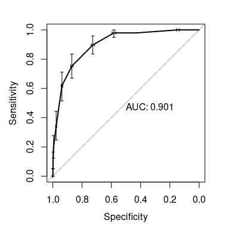

```r
plot(et_3)
```

Note that the AUC is almost as large as the AUC from the actual model fit. However there are fewer local maximas, and therefore fewer choices for screening thresholds. Again, the screening thresholds for the scores based on the sums of the question weights can be printed:

```r
qw_maximas <- get_what(from = et_3, what = "ROCci")
print(qw_maximas)
```

```
#>   Threshold Sensitivity    se.lcl    se.ucl Specificity    sp.lcl    sp.ucl
#> 1         1   1.0000000 1.0000000 1.0000000   0.1448416 0.1362019 0.1541589
#> 2         3   0.9793814 0.9484536 1.0000000   0.5829239 0.5702185 0.5954642
#> 3         4   0.8969072 0.8350515 0.9587629   0.7264103 0.7150601 0.7384381
#> 4         5   0.7525773 0.6597938 0.8350515   0.8698967 0.8614264 0.8782018
```

**NOTE:** Screening questions for which the question weights equal 0 can and should be eliminated from the clinical screening form.

How will implementation of that screening tool affect testing? To help answer that question, we can compute the ratio of total number of tests performed to the anticipated number of positive test results and the anticipated prevalence among those who are screened *out* of testing using the `ntpp` (number of tests per positive) function:

```r
ntpp(et_3)
```

```
#>    sensitivity specificity       prev      ntpp prev_untested
#> 1   1.00000000   0.0000000 0.01616667 61.855670           NaN
#> 2   1.00000000   0.1448416 0.01616667 53.041237  0.0000000000
#> 3   0.97938144   0.4318143 0.01616667 36.305263  0.0007840063
#> 4   0.97938144   0.5827545 0.01616667 26.926316  0.0005810575
#> 5   0.89690722   0.7265797 0.01616667 19.551724  0.0023261224
#> 6   0.75257732   0.8698967 0.01616667 11.520548  0.0046520644
#> 7   0.61855670   0.9374894 0.01616667  7.150000  0.0066415365
#> 8   0.34020619   0.9771303 0.01616667  5.090909  0.0109739369
#> 9   0.19587629   0.9950872 0.01616667  2.526316  0.0131048387
#> 10  0.10309278   0.9984754 0.01616667  1.900000  0.0145460625
#> 11  0.02061856   0.9994918 0.01616667  2.500000  0.0158465388
#> 12  0.00000000   1.0000000 0.01616667       NaN  0.0161666667
```

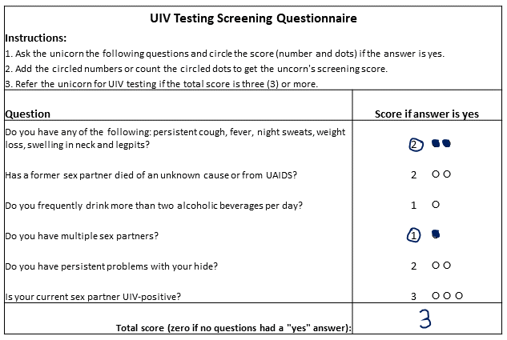

```r
knitr::include_graphics("UniTool.png")
```

**NOTE:** Screening questions for which the question weights equal 0 can and should be eliminated from the screening form.

## External validation on entirely new data

The estimates of screening performance based on cross-validation using only the training data will hold for screening on entirely new subjects if and only if those new subjects are from the same statistical population as the subjects in the training sample. However, subjects from other geographic areas, demographic groups and other health facilities may differ from those in the training sample. In that case, cross-validated estimates of sensitivity and specificity might still be overly optimistic. **Therefore it is highly desirable to validate the screening tool prior to use in new populations of subjects.**

External validation requires a repetition of the study for the new population(s). For example, a follow-up study was performed on unicorns who sought care at facilities that were not represented in the screening sample. A total of 3000 new unicorns were interviewed and tested for UIV as part of that follow-up study. External validation consists of assessment of the performance of the screening tool on those new subjects.

The `predict` method provides the means predict test-positivity among the new subjects:

```r
new_preds <- predict(uniobj1, newdata = val_data)
head(new_preds)
```

```
#>   testresult Q1 Q2 Q3 Q4 Q5 Q6 Q7  phat_minAIC phat_minBIC
#> 1          0  0  0  0  1  0  0  1 0.0011986840 0.001923221
#> 2          0  0  0  0  1  1  1  1 0.0105676565 0.009262256
#> 3          0  1  0  0  1  1  1  1 0.1453561278 0.099391653
#> 4          0  0  0  0  0  0  0  1 0.0011986840 0.001923221
#> 5          0  0  0  0  0  0  1  0 0.0007424381 0.001076885
#> 6          0  0  0  0  0  0  0  1 0.0011986840 0.001923221
```

Note that we are predicting using the results from the initial study, as contained in `uniobj1`. The data frame `val_data` contains the new data from the follow-up study.

The data frame `newpreds` contains the results of tests from the new subjects and predicted probabilities of a positive outcome based on the AIC- and BIC-best models fitted to the training data. The questionnaire responses from the new subjects are also included. Those are needed to assess performance of simplified screening based on the sums of question weights.

The performance of the screening tool when applied to the new subjects is again measured using the ROC.

The ROC for testing in the new subjects is obtained using the `roc` function from the `pROC` package:

```r
new_roc <- pROC::roc(testresult ~ phat_minAIC, data = new_preds,
auc = TRUE)
class(new_roc)
```

```
#> [1] "roc"
```

The `pROC` package provides a plot method for `roc`-class objects:

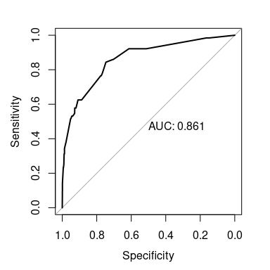

```r
plot(new_roc, print.auc = TRUE)
```

Note that the AUC is slightly smaller than the AUC from cross-validation of the training data. However the `roc_ci` function provided by the `screenr` package provides more informative information, including confidence intervals for sensitivity and specificity:

```r
new_perf <- roc_ci(new_roc, se.min = 0.8)
print(new_perf)
```

```
#>     Threshold Sensitivity   se.lcl    se.ucl Specificity    sp.lcl    sp.ucl
#> 1 0.000000000    1.000000 1.000000 1.0000000   0.0000000 0.0000000 0.0000000
#> 2 0.000970561    0.984375 0.953125 1.0000000   0.1648501 0.1515668 0.1781335
#> 3 0.006524469    0.921875 0.859375 0.9843750   0.6134196 0.5963811 0.6301090
#> 4 0.008154217    0.859375 0.765625 0.9375000   0.7067439 0.6903951 0.7224200
#> 5 0.008689076    0.843750 0.750000 0.9222656   0.7469346 0.7312670 0.7622616
#> 6 0.009894748    0.812500 0.718750 0.9062500   0.7568120 0.7411444 0.7721390
```

# Epilogue

The `screenr` package eases the workload for development and evaluation of screening tools. Hopefully `screenr` will prove useful to both novice and experienced R users. This tutorial documents only the basic steps. However much more is possible. Execute `help(screenr)` in an R session to obtain a broader list of capabilities. End-users are encouraged to further explore the methods that are available for objects. Make use of the R commands `class(some_object)` and `methods(class = "some_class")` where `some_object` is the result of some function call, and `"some_class"` is the class of that object. Then use `help(methodname.some_class)` to obtain help for use of method `methodname`.

Some may want results that are not directly available from `screenr` functions and methods. In those cases, the `get_what` methods may provide an easy way to extract the results contained in the objects produced by, for example, the `glmpath::glmpath` and `pROC::roc` functions. However, experienced R users will make use of `str(some_object)` to identify other components for extraction using the idiom `some_object$some_component`.

# References

1. Clemens SL, Macneal KD, Alons CL, Cohn JE. Screening algorithms to reduce burden of pediatric HIV testing: A systematic review and meta-analysis. The Pediatric Infectious Disease Journal. 2020; 39(10):e303-e309. DOI: 10.1097/INF.0000000000002715.
2. Hastie T, Tibshirani R, Friedman R. The Elements of Statistical Learning. Springer, New York. 2009. DOI: 10.1007/b94608.
3. Park MY, Hastie T. *L*1-regularization path algorithm for generalized linear models. Journal of the Royal Statistical Society Series B. 2007; 69(4):659-677. DOI: 10.1111/j.1467-9868.2007.00607.x
4. Linden A. Measuring diagnostic and predictive accuracy in disease management: an introduction to receiver operating characteristic (ROC) analysis. Journal of Evaluation in Clinical Practice. 2006; 12(2):132-139. DOI: 10.1111/j.1365-2753.2005.00598.x
5. Fawcett T. An introduction to ROC analysis. Pattern Recognition Letters. 2006; 27(8):861-874. DOI: 10.1016/j.patrec.2005.10.010.
6. Robin X, Turck N, Hainard A, Tiberti N, Lisacek F, Sanchez J-C, Müller M. pROC: an open-source package for R and S+ to analyze and compare ROC curves. BMC Bioinformatics. 2011; 12(77):1-8. DOI: 10.1186/1471-2105-12-77.